# DatZ6057 : Matemātiskās statistikas izvēlētas nodaļas

2.mājas darbs, Dāvis Sporāns DS16042

8.lekcija

1. uzdevums

Amerikas Automobiļu Asociācija publicēja datus (Defensive Driving:Managing Time and Space, 1991), kur analizē atkarību starp vidējo apstāšanos laiku (y = distance, in feet) mašīnas ātrumu (x = speed, in miles per hour). Dati carstopping.txt satur 63 novērojumus. Vai determinācijas koeficients R2 ir nozīmīgs ar lielu vērtību? Vai regresijas lineārā taisne labi pieguļ datu punktiem?

Ielasa datus un veic aprakstošo analīzi.

```r
dati<-read.table(file="carstopping.txt",header=T)
attach(dati)
fit<-lm(StopDist~Speed)
summary(fit)
```

```
Call:
lm(formula = StopDist ~ Speed)

Residuals:
    Min      1Q  Median      3Q     Max
-25.141  -7.300  -2.141   6.044  35.946

Coefficients:
            Estimate Std. Error t value Pr(>|t|)
(Intercept) -20.2734     3.2384   -6.26 4.25e-08 ***
Speed         3.1366     0.1517   20.68  < 2e-16 ***
---
Signif. codes:  0 ‘***’ 0.001 ‘**’ 0.01 ‘*’ 0.05 ‘.’ 0.1 ‘ ’ 1

Residual standard error: 11.8 on 61 degrees of freedom
Multiple R-squared:  0.8752,    Adjusted R-squared:  0.8731
F-statistic: 427.7 on 1 and 61 DF,  p-value: < 2.2e-16
```

Determinācijas koeficients 0.8752 Regresijas koeficienti nozīmīgi un arī f-tests norāda uz nozīmību

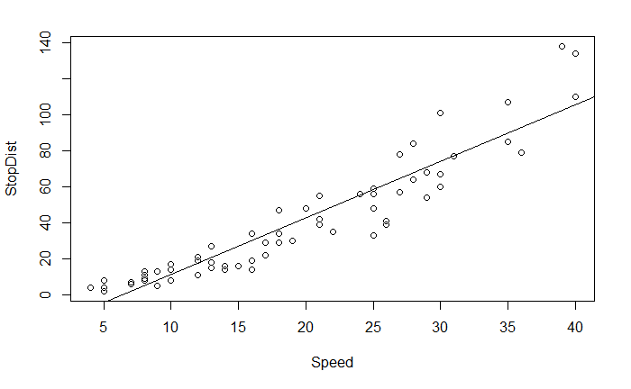

```r
# regresijas lineārā taisne
plot(Speed,StopDist)
abline(fit)
```

Lineārā regresijas taisne labi pieguļ datu punktiem. Aptuveni 88% no kopējās dispersijas izskaidrots ar vienkāršās lineārās regresijas palīdzību.

```r
detach(dati)
```

2. uzdevums

Aplūkosim sekojošus datus practical.txt. Veikt lineāro regresijas analīzi: novērtēt koeficientus, pārbaudīt vai tie ir statististki nozīmīgi, aprēķināt determinācijas koeficientu R2, aprēķināt ticamības intervālus regresijas koeficientiem. Vai 0 ietilpst ticamības intervālā slīpuma koeficientam b? Vai b ir statistiski nozīmīgs? Komentēt: kāpēc šāda pretruna: lai gan slīpuma koeficients b ir tuvu nullei, tomēr tas ir statistiski nozīmīgs.

Ielasa datus un uzzīmē izkliedes garfiku, novelk regresijas taisni.

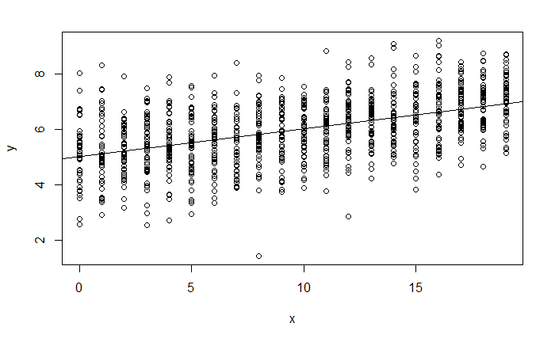

```r
dati2<-read.table(file="practical.txt",header=T)
attach(dati2)
plot(x,y)
fit2<-lm(y~x)
abline(fit2)
```

```r
summary(fit2)
```

```
Call:
lm(formula = y ~ x)

Residuals:
    Min      1Q  Median      3Q     Max
-4.3623 -0.6559  0.0131  0.6818  3.1889

Coefficients:
            Estimate Std. Error t value Pr(>|t|)
(Intercept) 5.006235   0.061969   80.79   <2e-16 ***
x           0.099798   0.005576   17.90   <2e-16 ***
---
Signif. codes:  0 ‘***’ 0.001 ‘**’ 0.01 ‘*’ 0.05 ‘.’ 0.1 ‘ ’ 1

Residual standard error: 1.017 on 998 degrees of freedom
Multiple R-squared:  0.243, Adjusted R-squared:  0.2422
F-statistic: 320.3 on 1 and 998 DF,  p-value: < 2.2e-16
```

Koeficienti statistiski nozīmīgi.

Determinācijas koeficients: 0.243

Slīpuma koeficients: 0.099

Lai gan slīpuma koeficents nav liels, bet ja vien koeficients nav 0, tad tā statistikso nozīmību neietekmē tā vērtība.

```r
tic_int<-confint(fit2, level = 0.95);tic_int
```

```
                 2.5 %    97.5 %
(Intercept) 4.88463068 5.1278402
x           0.08885531 0.1107403
```

Slīpuma koeficienta ticamības inervāls: [0.08885531 0.1107403], tajā neietilpst 0.

```r
detach(dati2)
```

9.lekcija

1. uzdevums

Ielasīt programmā R datus CMB. Līdzīgi kā lekcijā veikt lineārās un polinomiālās regresijas analīzi. Pārbaudīt ar ANOVA palīdzību, kura kārta polinomiālajai regresijai būtu piemērota. Veikt atlikumu analīzi līdzīgi kā lekcijā.

Ielasa datus, uzzīmē izkliedes grafiku un regresijas taisni.Veic aprakstošo analīzi.

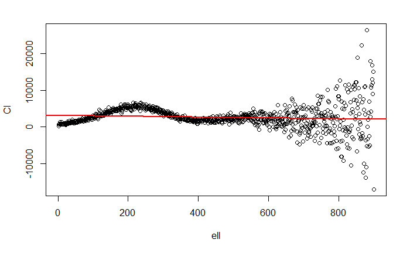

```r
#detach(dati)
library(car)
dati<-read.table("cmb.txt", header=T)
attach(dati)
plot(Cl~ell)
fit1<-lm(Cl~ell)
abline(fit1,col="red",lwd=2)
```

```r
summary(fit1)
```

```
Call:
lm(formula = Cl ~ ell)

Residuals:
     Min       1Q   Median       3Q      Max
-19163.1  -1330.3   -265.5   1405.5  24338.5

Coefficients:
             Estimate Std. Error t value Pr(>|t|)
(Intercept) 3261.1891   220.7702  14.772  < 2e-16 ***
ell           -1.2714     0.4243  -2.996  0.00281 **
---
Signif. codes:  0 ‘***’ 0.001 ‘**’ 0.01 ‘*’ 0.05 ‘.’ 0.1 ‘ ’ 1

Residual standard error: 3301 on 897 degrees of freedom
Multiple R-squared:  0.009911,  Adjusted R-squared:  0.008807
F-statistic: 8.979 on 1 and 897 DF,  p-value: 0.002806
```

Koeficienti nozīmīgi, tomēr mazs determinācijas koeficients (0.009911), tas nozīmē, ka lineārais modelis slikti paskaidro datus.

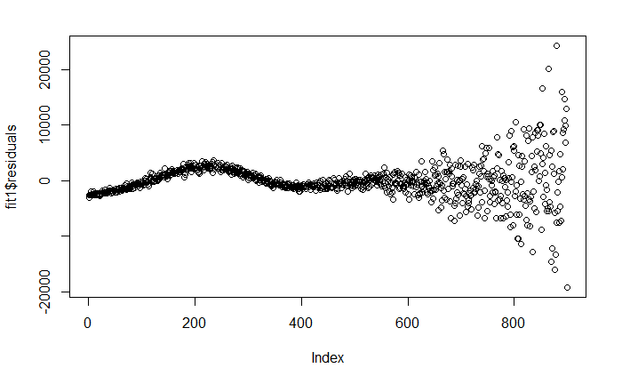

```r
plot(fit1$residuals)
```

Tā kā regresijas taisnei ir mazs slīpuma koeficients atlikumu grafiks ir līdzīgs oriģinālajam.

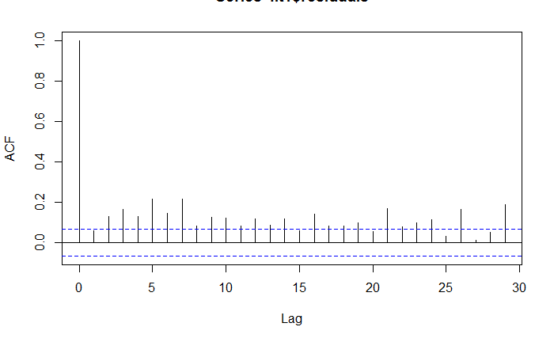

```r
acf(fit1$residuals)
```

```r
durbinWatsonTest(fit1,max.lag = 5)
```

```
 lag Autocorrelation D-W Statistic p-value
   1      0.05972642      1.841981   0.016
   2      0.12981804      1.683936   0.000
   3      0.16315187      1.606641   0.000
   4      0.13083567      1.665959   0.000
   5      0.21735551      1.470333   0.000
 Alternative hypothesis: rho[lag] != 0
```

Polinomiālās regresijas analīze.

```r
fit1<-lm(Cl~poly(ell,degree=2,raw=T))
fit2<-lm(Cl~poly(ell,degree=3,raw=T))
summary(fit2)
```

```
Call:
lm(formula = Cl ~ poly(ell, degree = 3, raw = T))

Residuals:
     Min       1Q   Median       3Q      Max
-21625.0  -1055.4   -127.2   1044.2  22512.1

Coefficients:
                                  Estimate Std. Error t value Pr(>|t|)
(Intercept)                      5.337e+02  4.265e+02   1.251    0.211
poly(ell, degree = 3, raw = T)1  3.407e+01  4.088e+00   8.333 2.95e-16 ***
poly(ell, degree = 3, raw = T)2 -9.669e-02  1.052e-02  -9.189  < 2e-16 ***
poly(ell, degree = 3, raw = T)3  7.093e-05  7.669e-06   9.248  < 2e-16 ***
---
Signif. codes:  0 ‘***’ 0.001 ‘**’ 0.01 ‘*’ 0.05 ‘.’ 0.1 ‘ ’ 1

Residual standard error: 3157 on 895 degrees of freedom
Multiple R-squared:  0.09644,   Adjusted R-squared:  0.09341
F-statistic: 31.84 on 3 and 895 DF,  p-value: < 2.2e-16
```

```r
anova(fit1,fit2)
```

```
Analysis of Variance Table

Model 1: Cl ~ poly(ell, degree = 2, raw = T)
Model 2: Cl ~ poly(ell, degree = 3, raw = T)
  Res.Df        RSS Df Sum of Sq      F    Pr(>F)
1    896 9775159589
2    895 8922465537  1 852694052 85.532 < 2.2e-16 ***
---
Signif. codes:  0 ‘***’ 0.001 ‘**’ 0.01 ‘*’ 0.05 ‘.’ 0.1 ‘ ’ 1
```

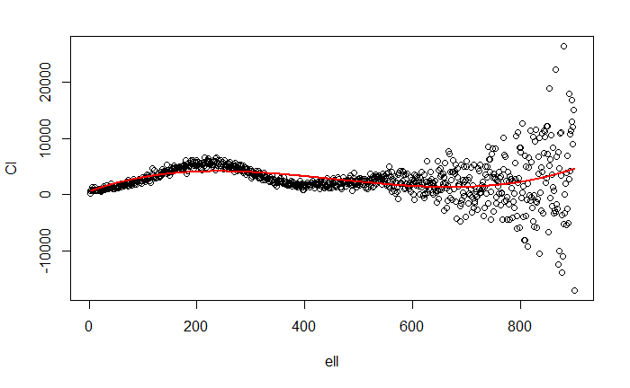

```r
plot(Cl~ell)
lines(sort(ell), fitted(fit2)[order(ell)], col='red', lwd=2)
```

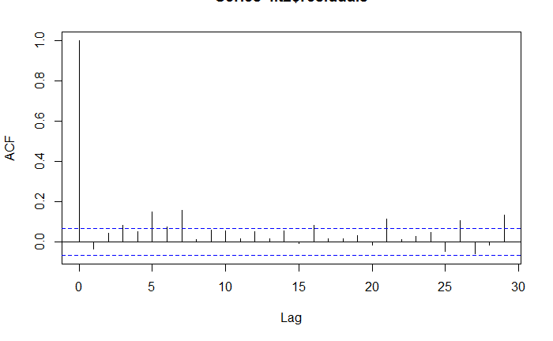

```r
acf(fit2$residuals)
```

```r
durbinWatsonTest(fit2,max.lag = 5)
```

```
 lag Autocorrelation D-W Statistic p-value
   1     -0.03547383      2.018511   0.854
   2      0.04494388      1.845274   0.026
   3      0.08424184      1.760394   0.000
   4      0.05067233      1.825164   0.006
   5      0.14967925      1.610167   0.000
 Alternative hypothesis: rho[lag] != 0
```

```r
detach(dati)
```

2. uzdevums

Ielasīt programmā R datus LifeCycleSavings, kas raksturo ietaupījumu attiecību pret ienākumiem atkarībā no pieciem faktoriem. Līdzīgi kā otrajā uzdevumā veikt daudzfaktoru lienāro regresijas analīzi. Novērtēt arī atbilstošās korelācijas. Pārbaudīt modeļa nosacījumus, veikt diagnostiku, apskatīt mainīgo selekcijas problēmu. Veikt atbisltošus secinājumus.

Ielasa datus, aplūko kolerācijas.

```r
attach(LifeCycleSavings)
cor(LifeCycleSavings , method="kendall")
```

```
              sr      pop15       pop75         dpi        ddpi
sr     1.0000000 -0.2776644  0.21758708  0.18293182  0.29423787
pop15 -0.2776644  1.0000000 -0.69256021 -0.57061224 -0.12500004
pop75  0.2175871 -0.6925602  1.00000000  0.60425265  0.05319151
dpi    0.1829318 -0.5706122  0.60425265  1.00000000  0.02205883
ddpi   0.2942379 -0.1250000  0.05319151  0.02205883  1.00000000
```

```r
fit<-lm(sr~.,data=LifeCycleSavings)
summary(fit)
```

```
Call:
lm(formula = sr ~ ., data = LifeCycleSavings)

Residuals:
    Min      1Q  Median      3Q     Max
-8.2422 -2.6857 -0.2488  2.4280  9.7509

Coefficients:
              Estimate Std. Error t value Pr(>|t|)
(Intercept) 28.5660865  7.3545161   3.884 0.000334 ***
pop15       -0.4611931  0.1446422  -3.189 0.002603 **
pop75       -1.6914977  1.0835989  -1.561 0.125530
dpi         -0.0003369  0.0009311  -0.362 0.719173
ddpi         0.4096949  0.1961971   2.088 0.042471 *
---
Signif. codes:  0 ‘***’ 0.001 ‘**’ 0.01 ‘*’ 0.05 ‘.’ 0.1 ‘ ’ 1

Residual standard error: 3.803 on 45 degrees of freedom
Multiple R-squared:  0.3385,    Adjusted R-squared:  0.2797
F-statistic: 5.756 on 4 and 45 DF,  p-value: 0.0007904
```

Koeficients ‘dpi’ vismazāk nozīmīgs. Izņem to no modeļa un novērtē, vai ir uzlabojums.

```r
fit1<-lm(sr ~ pop15 + pop75 + ddpi, data = LifeCycleSavings)
summary(fit1)
```

```
Call:
lm(formula = sr ~ pop15 + pop75 + ddpi, data = LifeCycleSavings)

Residuals:
    Min      1Q  Median      3Q     Max
-8.2539 -2.6159 -0.3913  2.3344  9.7070

Coefficients:
            Estimate Std. Error t value Pr(>|t|)
(Intercept)  28.1247     7.1838   3.915 0.000297 ***
pop15        -0.4518     0.1409  -3.206 0.002452 **
pop75        -1.8354     0.9984  -1.838 0.072473 .
ddpi          0.4278     0.1879   2.277 0.027478 *
---
Signif. codes:  0 ‘***’ 0.001 ‘**’ 0.01 ‘*’ 0.05 ‘.’ 0.1 ‘ ’ 1

Residual standard error: 3.767 on 46 degrees of freedom
Multiple R-squared:  0.3365,    Adjusted R-squared:  0.2933
F-statistic: 7.778 on 3 and 46 DF,  p-value: 0.0002646
```

```r
anova(fit,fit1)
```

```
Analysis of Variance Table

Model 1: sr ~ pop15 + pop75 + dpi + ddpi
Model 2: sr ~ pop15 + pop75 + ddpi
  Res.Df    RSS Df Sum of Sq      F Pr(>F)
1     45 650.71
2     46 652.61 -1   -1.8932 0.1309 0.7192
```

Pēc Anova testa p-vertiba>0.05, tāpēc nav vērā ņemama statiskā uzlabojuma. Arī determinācijas koeficients ir samazinājies .Tomēr keficienti statisti nozīmīgi, izņemot pop75, kura nozīmīgumu var apšaubīt (p-vērt=0.07).

10.lekcija

1. uzdevums

Aplūkot asinspiediena datus bloodpress.txt. Veikt daudzfaktoru regresiju, atlasot mainīgos (ievērojot multikolinearitāti) un veicot attiecīgo regresijas diagnostiku. Vai šeit ir nozīmīga mijiedarbība starp faktoriem?

Ielasa datus un veic modeļa aprakstošo analīzi.

```r
dati<-read.table("bloodpress.txt",header=T)
dati1<-dati[,-1]
attach(dati1)
fit<-lm(BP~.,data=dati1)
summary(fit)
```

```
Call:
lm(formula = BP ~ ., data = dati1)

Residuals:
     Min       1Q   Median       3Q      Max
-0.93213 -0.11314  0.03064  0.21834  0.48454

Coefficients:
              Estimate Std. Error t value Pr(>|t|)
(Intercept) -12.870476   2.556650  -5.034 0.000229 ***
Age           0.703259   0.049606  14.177 2.76e-09 ***
Weight        0.969920   0.063108  15.369 1.02e-09 ***
BSA           3.776491   1.580151   2.390 0.032694 *
Dur           0.068383   0.048441   1.412 0.181534
Pulse        -0.084485   0.051609  -1.637 0.125594
Stress        0.005572   0.003412   1.633 0.126491
---
Signif. codes:  0 ‘***’ 0.001 ‘**’ 0.01 ‘*’ 0.05 ‘.’ 0.1 ‘ ’ 1

Residual standard error: 0.4072 on 13 degrees of freedom
Multiple R-squared:  0.9962,    Adjusted R-squared:  0.9944
F-statistic: 560.6 on 6 and 13 DF,  p-value: 6.395e-15
```

Determinācijas koeficients = 99%, arī t-tests uzrāda statisku nozīmību, tomēr ne visi koeficienti ir statistiksi nozīmīgi.

```r
library(car)
sort(vif(fit)) #weight pārsniedz 4 (vif=8), aizdomas par multikolirinitāti
```

```
     Dur      Age   Stress    Pulse      BSA   Weight
1.237309 1.762807 1.834845 4.413575 5.328751 8.417035
```

```r
#cor(dati1)[1,]
```

Veicot VIF, weight pārsniedz 4 (vif=8.417035), ir aizdomas par multikolirinitāti. No modeļa izņem weight un novēro, vai tas dod uzlabojumu.

```r
fit1<-lm(BP~.,data=dati1[,-3]) #modelis bez weight
summary(fit1)
```

```
Call:
lm(formula = BP ~ ., data = dati1[, -3])

Residuals:
    Min      1Q  Median      3Q     Max
-2.3687 -0.9135  0.1546  0.9053  2.8020

Coefficients:
            Estimate Std. Error t value Pr(>|t|)
(Intercept)  6.21215    9.42927   0.659   0.5207
Age          0.56297    0.20572   2.737   0.0161 *
BSA         24.55378    3.45160   7.114 5.22e-06 ***
Dur          0.07682    0.20437   0.376   0.7126
Pulse        0.45644    0.15925   2.866   0.0124 *
Stress      -0.01673    0.01303  -1.284   0.2199
---
Signif. codes:  0 ‘***’ 0.001 ‘**’ 0.01 ‘*’ 0.05 ‘.’ 0.1 ‘ ’ 1

Residual standard error: 1.718 on 14 degrees of freedom
Multiple R-squared:  0.9262,    Adjusted R-squared:  0.8998
F-statistic: 35.14 on 5 and 14 DF,  p-value: 1.921e-07
```

```r
sort(vif(fit1))
```

```
     Dur      BSA   Stress      Age    Pulse
1.237151 1.428349 1.502936 1.703115 2.360939
```

Būtisks uzlabojums nav novērojams, tomēr visi VIF koeficienti ir mazāki par 4, tāpēc dispersija nav ietekmēta.

```r
step(fit1)
```

```
Start:  AIC=26.52
BP ~ Age + BSA + Dur + Pulse + Stress

         Df Sum of Sq     RSS    AIC
- Dur     1     0.417  41.745 24.717
<none>                 41.328 26.516
- Stress  1     4.869  46.196 26.743
- Age     1    22.107  63.435 33.086
- Pulse   1    24.249  65.577 33.750
- BSA     1   149.385 190.713 55.101

Step:  AIC=24.72
BP ~ Age + BSA + Pulse + Stress

         Df Sum of Sq     RSS    AIC
<none>                 41.745 24.717
- Stress  1     4.622  46.366 24.817
- Age     1    23.296  65.040 31.586
- Pulse   1    26.570  68.315 32.568
- BSA     1   148.968 190.713 53.101

Call:
lm(formula = BP ~ Age + BSA + Pulse + Stress, data = dati1[,
    -3])

Coefficients:
(Intercept)          Age          BSA        Pulse       Stress
    5.50082      0.57301     24.48547      0.46830     -0.01621
```

Izmantojot mainīgo selekciju ar AIC, izvēlēts modelī neiekļaut arī mainīgo Dur.

```r
fit2<-lm(formula = BP ~ Age + BSA + Pulse + Stress, data = dati1)
summary(fit2)
```

```
Call:
lm(formula = BP ~ Age + BSA + Pulse + Stress, data = dati1)

Residuals:
    Min      1Q  Median      3Q     Max
-2.5519 -0.8068  0.1494  0.7891  2.8867

Coefficients:
            Estimate Std. Error t value Pr(>|t|)
(Intercept)  5.50082    8.96912   0.613  0.54886
Age          0.57301    0.19805   2.893  0.01115 *
BSA         24.48547    3.34670   7.316 2.54e-06 ***
Pulse        0.46830    0.15156   3.090  0.00747 **
Stress      -0.01621    0.01258  -1.289  0.21704
---
Signif. codes:  0 ‘***’ 0.001 ‘**’ 0.01 ‘*’ 0.05 ‘.’ 0.1 ‘ ’ 1

Residual standard error: 1.668 on 15 degrees of freedom
Multiple R-squared:  0.9255,    Adjusted R-squared:  0.9056
F-statistic: 46.56 on 4 and 15 DF,  p-value: 2.773e-08
```

Iegūts piemērotākais modelis ar determinācijas koeficientu = 0.9255, visi mainīgie nozīmīgi, izņemot Stress.

```r
fitm<-lm(BP ~ Age * BSA * Pulse * Stress, data = dati1)
summary(fitm)
```

```
Call:
lm(formula = BP ~ Age * BSA * Pulse * Stress, data = dati1)

Residuals:
       1        2        3        4        5        6        7        8        9       10
 0.94773 -0.11045  0.52923  1.02869 -0.05404 -0.14234  0.19669 -0.99274 -0.93770  1.18985
      11       12       13       14       15       16       17       18       19       20
-0.69876  0.60057 -1.38376 -0.60260  0.22397  0.15287 -0.35205  0.23934  0.51214 -0.34665

Coefficients:
                       Estimate Std. Error t value Pr(>|t|)
(Intercept)          -5.328e+04  5.832e+04  -0.914    0.413
Age                   1.140e+03  1.227e+03   0.929    0.405
BSA                   2.800e+04  3.060e+04   0.915    0.412
Pulse                 7.627e+02  8.424e+02   0.905    0.416
Stress                3.305e+02  6.548e+02   0.505    0.640
Age:BSA              -5.982e+02  6.435e+02  -0.930    0.405
Age:Pulse            -1.629e+01  1.772e+01  -0.919    0.410
BSA:Pulse            -3.996e+02  4.418e+02  -0.905    0.417
Age:Stress           -7.335e+00  1.370e+01  -0.535    0.621
BSA:Stress           -1.837e+02  3.452e+02  -0.532    0.623
Pulse:Stress         -4.808e+00  9.383e+00  -0.512    0.635
Age:BSA:Pulse         8.542e+00  9.290e+00   0.919    0.410
Age:BSA:Stress        4.074e+00  7.226e+00   0.564    0.603
Age:Pulse:Stress      1.063e-01  1.963e-01   0.541    0.617
BSA:Pulse:Stress      2.659e+00  4.942e+00   0.538    0.619
Age:BSA:Pulse:Stress -5.877e-02  1.034e-01  -0.568    0.600

Residual standard error: 1.529 on 4 degrees of freedom
Multiple R-squared:  0.9833,    Adjusted R-squared:  0.9206
F-statistic:  15.7 on 15 and 4 DF,  p-value: 0.008273
```

Iegūtajam modelim netiek novērota savstarpējā mainīgo mijiedarbība.

2. uzdevums

Veikt ANOVA analīzi datiem, kurus izmantojām kontroldarbā par bērnu lasītprasmi. Pamatot ar Tukey post-hoc testa analīzi, no kura vecuma bērnu lasītprasme vairs nemainās.

Ielasa datus un uzzīmē kastu garfikus.

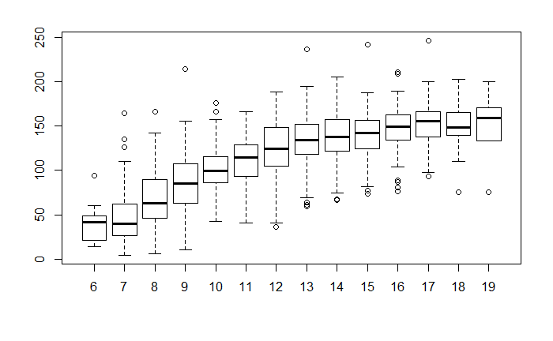

```r
dati<-read.csv("dati_lasitprasme.csv", header=TRUE, stringsAsFactors = FALSE)
names_dat<-c("Dzimums","VardiMin","TMTA","TMTB","Vecums")
names(dati)<-names_dat
attach(dati)
boxplot(VardiMin~Vecums)
```

Izveido modeli, kas apskata vārdus/minūtē pret vecumu un veic aprakstošo analīzi.

```r
fit<-aov(VardiMin~as.factor(Vecums))
summary(fit)
```

```
                    Df  Sum Sq Mean Sq F value Pr(>F)
as.factor(Vecums)   13 2126867  163605   223.3 <2e-16 ***
Residuals         1930 1413873     733
---
Signif. codes:  0 ‘***’ 0.001 ‘**’ 0.01 ‘*’ 0.05 ‘.’ 0.1 ‘ ’ 1
221 observations deleted due to missingness
```

Visām vecuma grupām vidējā vērtiba nav vienāda (p-vērt<0.05), veic Tukey post-hoc testa analīzi, lai noskaidrotu, no kura vecuma lasītprasmes ātrums nemainās.

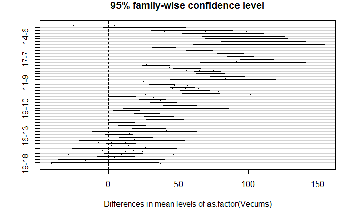

```r
plot(TukeyHSD(fit))
```

```r
TukeyHSD(fit)
```

```
  Tukey multiple comparisons of means
    95% family-wise confidence level

Fit: aov(formula = VardiMin ~ as.factor(Vecums))

$`as.factor(Vecums)`
            diff         lwr       upr     p adj
7-6     4.252817 -25.2308781  33.73651 0.9999999
8-6    25.878119  -3.7058148  55.46205 0.1627791
9-6    43.859278  14.4921272  73.22643 0.0000510
10-6   59.650444  30.1219632  89.17893 0.0000000
11-6   69.366854  39.8869795  98.84673 0.0000000
12-6   82.068387  52.5441990 111.59257 0.0000000
13-6   91.179955  61.6471332 120.71278 0.0000000
14-6   96.602031  67.1370515 126.06701 0.0000000
15-6   98.835273  69.2362335 128.43431 0.0000000
16-6  105.454545  75.4356407 135.47345 0.0000000
17-6  110.730593  80.2671662 141.19402 0.0000000
18-6  109.678517  78.5584145 140.79862 0.0000000
19-6  107.758000  60.8242854 154.69171 0.0000000
8-7    21.625302  12.0119145  31.23869 0.0000000
9-7    39.606461  30.6824704  48.53045 0.0000000
10-7   55.397628  45.9562672  64.83899 0.0000000
11-7   65.114037  55.8258140  74.40226 0.0000000
12-7   77.815570  68.3876462  87.24349 0.0000000
13-7   86.927139  77.4722106  96.38207 0.0000000
14-7   92.349214  83.1083765 101.59005 0.0000000
15-7   94.582456  84.9226833 104.24223 0.0000000
16-7  101.201729  90.3231844 112.08027 0.0000000
17-7  106.477776  94.4266999 118.52885 0.0000000
18-7  105.425700  91.7996637 119.05174 0.0000000
19-7  103.505183  65.8225393 141.18783 0.0000000
9-8    17.981158   8.7313756  27.23094 0.0000000
10-8   33.772325  24.0224449  43.52221 0.0000000
11-8   43.488735  33.8870699  53.09040 0.0000000
12-8   56.190268  46.4533982  65.92714 0.0000000
13-8   65.301836  55.5388171  75.06486 0.0000000
14-8   70.723912  61.1680780  80.27975 0.0000000
15-8   72.957154  62.9956232  82.91868 0.0000000
16-8   79.576426  68.4290677  90.72379 0.0000000
```

[output cut: 43 more lines]

```
15-14   2.233242  -7.3692543  11.83574 0.9999573
16-14   8.852515  -1.9752022  19.68023 0.2538983
17-14  14.128562   2.1233481  26.13378 0.0061630
18-14  13.076487  -0.5090059  26.66198 0.0732064
19-14  11.155969 -26.5120327  48.82397 0.9993687
16-15   6.619273  -4.5681125  17.80666 0.7761343
17-15  11.895320  -0.4352638  24.22590 0.0716550
18-15  10.843245  -3.0306065  24.71710 0.3252481
19-15   8.922727 -28.8502329  46.69569 0.9999489
17-16   5.276047  -8.0308988  18.58299 0.9885088
18-16   4.223972 -10.5244267  18.97237 0.9995599
19-16   2.303455 -35.7994067  40.40632 1.0000000
18-17  -1.052075 -16.6854039  14.58125 1.0000000
19-17  -2.972593 -41.4266397  35.48145 1.0000000
19-18  -1.920517 -40.8968458  37.05581 1.0000000
```

11.lekcija

1. uzdevums

Optometru datiem par bērnu lasītprasmi (kas izmantoti eksāmenā un ielikti serverī) veikt ANOVA analīzi, aizstājot novērojumus ar viņu rangiem. Pārbaudīt, no kura vecuma (un klases) lasītprasme vairs statistiski nozīmīgi neat- šķiras. Parādīt tabulas formā iegūtās Tukey post-hoc testa p-vērtības un salīdzināt, kur ir iegūtas lielākās atšķirības ar klasisko ANOVA analīzi.

```r
kruskal.test(VardiMin,Vecums)
```

```
    Kruskal-Wallis rank sum test

data:  VardiMin and Vecums
Kruskal-Wallis chi-squared = 1130.7, df = 13, p-value < 2.2e-16
```

Kruskal tests uzrāda. ka vidējās vērtības pa rangiem nav vienādas (p-vērt<0.05), salīdzina rangus pa pāriem izmantojot R pakotnes PMCMR funkciju posthoc.kruskal.nemenyi.test.

```r
require(PMCMR)
post_hoc<-posthoc.kruskal.nemenyi.test(x=VardiMin, g=Vecums, dist="Tukey")
```

```
Ties are present, p-values are not corrected.
```

```r
post_hoc$p.value
```

```
              6            7            8            9           10           11           12
7  1.000000e+00           NA           NA           NA           NA           NA           NA
8  9.918090e-01 6.546524e-02           NA           NA           NA           NA           NA
9  5.489966e-01 6.485433e-10 7.521045e-02           NA           NA           NA           NA
10 4.926621e-02 1.463274e-13 3.197681e-08 3.543470e-02           NA           NA           NA
11 2.404759e-03 0.000000e+00 1.026956e-13 4.925876e-08 3.827451e-01           NA           NA
12 1.589403e-05 0.000000e+00 0.000000e+00 1.141309e-13 8.282440e-07 5.942495e-02           NA
13 2.105477e-07 0.000000e+00 0.000000e+00 0.000000e+00 2.541301e-13 1.468330e-06 5.359687e-01
14 1.428377e-08 0.000000e+00 0.000000e+00 0.000000e+00 1.137979e-13 1.210945e-10 1.723496e-02
15 4.007022e-09 0.000000e+00 0.000000e+00 0.000000e+00 1.487699e-13 8.008816e-12 2.331743e-03
16 1.544409e-10 0.000000e+00 0.000000e+00 0.000000e+00 1.155742e-13 1.961764e-13 1.333066e-05
17 3.157674e-11 0.000000e+00 0.000000e+00 0.000000e+00 1.557643e-13 1.889600e-13 2.497520e-06
18 1.280969e-10 0.000000e+00 0.000000e+00 0.000000e+00 1.054712e-13 7.957934e-11 1.163221e-04
19 5.958428e-04 5.346687e-06 4.021364e-04 1.048991e-02 1.525683e-01 5.330375e-01 9.673539e-01
           13        14        15        16 17 18
7          NA        NA        NA        NA NA NA
8          NA        NA        NA        NA NA NA
9          NA        NA        NA        NA NA NA
10         NA        NA        NA        NA NA NA
11         NA        NA        NA        NA NA NA
12         NA        NA        NA        NA NA NA
13         NA        NA        NA        NA NA NA
14 0.99152493        NA        NA        NA NA NA
15 0.82690747 0.9999918        NA        NA NA NA
16 0.07524115 0.6625825 0.9675728        NA NA NA
17 0.01466395 0.2464358 0.6621963 0.9999795 NA NA
18 0.07817546 0.5180651 0.8629008 0.9999987  1 NA
19 0.99975456 0.9999984 1.0000000 1.0000000  1  1
```

2. uzdevums

Aprakstīt CMB datus no Larry Wasserman mājaslapas. Veikt polinomiālo un neparametrisko regresiju. Pārbaudīt nosacījumus, veikt diagnostiku. Izdarīt attiecīgus secinājumus.

Ielasa datus un uzzīmē izkliedes grafiku.

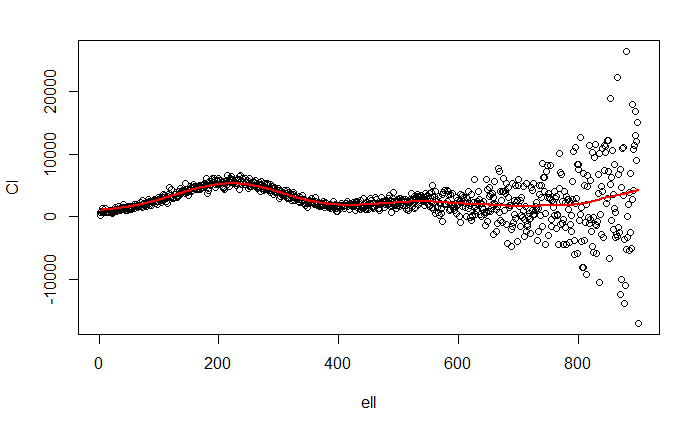

```r
dati<-read.table("cmb.txt", header=T)
attach(dati)
plot(Cl~ell)
library(KernSmooth)
h<-dpill(ell,Cl) # h nov�rt��anas metode
fit<-locpoly(ell,Cl,degree=0,bandwidth=h)
lines(fit,col="red",lwd=2)
```

Polinomiālā regresija šiem datiem tika veikta 9. lekcijas 1. uzdevumā, kur noskaidrojām, ka polinomiālā regresija nav piemērota lai paskaidrotu datus. Salīdzniot ar polinomiālo regresiju neparametriskā regresija dod uzlabojumu tieši robežās, kur iespējams prognozēt datus.